# Tests on mean values

## Introduction

Hypothesis tests and p-values

- Motivation
  - Population mean and sample mean
  - Understand the question
  - Explore the data
- Comparing **one-sample mean** to a known mean:
  - One-sample t-test (parametric)
  - One-sample Wilcoxon test (non-parametric)
- Comparing the **means of two independent groups**
  - Unpaired two samples t-test (parametric)
  - Unpaired two-samples Wilcoxon test (non-parametric)
- Comparing the **means of paired samples**
  - Paired samples t-test (parametric)
  - Paired samples Wilcoxon test (non-parametric)
- Comparing the **means of more than two groups**
  - One-way ANOVA test (parametric)
  - Kruskal-Wallis test (non parametric)

## Data example 1

Studies of pulmonary function in adults who are long-time smokers have shown that smoking tends to impair lung function. A question then arises as to whether similar effects can be detected in children who smoke. We will use **fev** data that include measures of lung function, forced expiratory volume (FEV), which were collected from 654 children seen for a routine checkup in a pediatric clinic. The study subjects were asked whether they were current smokers. FEV measures the volume of air you can blow out of your lungs.

```r
library(Hmisc)
#fev=read.csv("./data/fev.csv",header=TRUE,row.names=1)
fev <- read.csv("https://raw.githubusercontent.com/couthcommander/sip_computing/main/labs/fev.csv",header=TRUE,row.names=1)
label(fev$age) <- 'subject age at time of measurement (years)'
label(fev$fev) <- 'measured FEV (liters per second)'
label(fev$height) <- 'subject height at time of measurement (inches)'
label(fev$sex) <- 'sex (1 = male, 2 = female)'
label(fev$smoke) <- 'smoker (1 = smoker, 2 = non-smoker)'
head(fev)
```

```
##   age   fev height sex smoke
## 1   9 1.708   57.0   2     2
## 2   8 1.724   67.5   2     2
## 3   7 1.720   54.5   2     2
## 4   9 1.558   53.0   1     2
## 5   9 1.895   57.0   1     2
## 6   8 2.336   61.0   2     2
```

```r
html(describe(fev))
```

fev  
5 Variables 654 Observations

age: subject age at time of measurement (years)

| n | missing | distinct | Info | Mean | Gmd | .05 | .10 | .25 | .50 | .75 | .90 | .95 |
| --- | --- | --- | --- | --- | --- | --- | --- | --- | --- | --- | --- | --- |
| 654 | 0 | 17 | 0.988 | 9.931 | 3.3 | 5 | 6 | 8 | 10 | 12 | 14 | 15 |

lowest : 3 4 5 6 7 , highest: 15 16 17 18 19

```
 Value          3     4     5     6     7     8     9    10    11    12    13    14
 Frequency      2     9    28    37    54    85    94    81    90    57    43    25
 Proportion 0.003 0.014 0.043 0.057 0.083 0.130 0.144 0.124 0.138 0.087 0.066 0.038

 Value         15    16    17    18    19
 Frequency     19    13     8     6     3
 Proportion 0.029 0.020 0.012 0.009 0.005
```

fev: measured FEV (liters per second)

| n | missing | distinct | Info | Mean | Gmd | .05 | .10 | .25 | .50 | .75 | .90 | .95 |
| --- | --- | --- | --- | --- | --- | --- | --- | --- | --- | --- | --- | --- |
| 654 | 0 | 575 | 1 | 2.637 | 0.9681 | 1.445 | 1.612 | 1.981 | 2.547 | 3.119 | 3.813 | 4.289 |

lowest : 0.791 0.796 0.839 1.004 1.072 , highest: 5.102 5.224 5.633 5.638 5.793

height: subject height at time of measurement (inches)

| n | missing | distinct | Info | Mean | Gmd | .05 | .10 | .25 | .50 | .75 | .90 | .95 |
| --- | --- | --- | --- | --- | --- | --- | --- | --- | --- | --- | --- | --- |
| 654 | 0 | 56 | 0.999 | 61.14 | 6.497 | 51.0 | 53.0 | 57.0 | 61.5 | 65.5 | 68.5 | 70.0 |

lowest : 46.0 46.5 47.0 48.0 49.0 , highest: 72.0 72.5 73.0 73.5 74.0

sex: sex (1 = male, 2 = female)

| n | missing | distinct | Info | Mean | Gmd |
| --- | --- | --- | --- | --- | --- |
| 654 | 0 | 2 | 0.749 | 1.486 | 0.5004 |

```
 Value          1     2
 Frequency    336   318
 Proportion 0.514 0.486
```

smoke: smoker (1 = smoker, 2 = non-smoker)

| n | missing | distinct | Info | Mean | Gmd |
| --- | --- | --- | --- | --- | --- |
| 654 | 0 | 2 | 0.269 | 1.901 | 0.1793 |

```
 Value          1     2
 Frequency     65   589
 Proportion 0.099 0.901
```

## Comparing one-sample mean to a known mean

**Question**: Is the mean value of age in this data different from 10?

### Check data distribution to decide which test to use

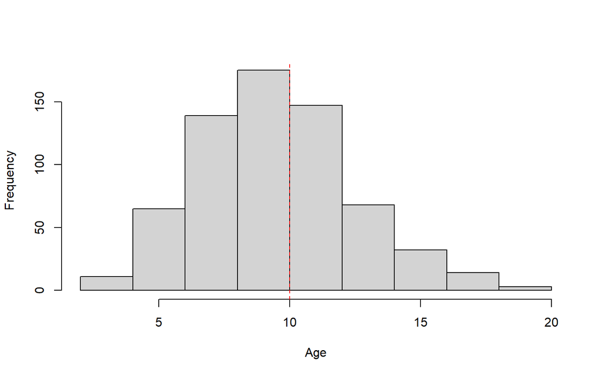

```r
hist(fev$age, main="", xlab="Age")
abline(v=10, lty=2, col="red")
```

### One-sample t-test (parametric)

```r
#T stastic caculation
cohortMean=mean(fev$age)
cohortSD=sd(fev$age)
cohortN=nrow(fev)
populationMean=10

TValue=(cohortMean-populationMean)/(cohortSD/sqrt(cohortN))
TValue
```

```
## [1] -0.5956932
```

```r
#one sample t test
t.test(fev$age, mu=populationMean)
```

```
##
##  One Sample t-test
##
## data:  fev$age
## t = -0.59569, df = 653, p-value = 0.5516
## alternative hypothesis: true mean is not equal to 10
## 95 percent confidence interval:
##   9.704381 10.158005
## sample estimates:
## mean of x
##  9.931193
```

The output of t.test() function is a list containing the following components:

- statistic: the value of the t-statistic
- p.value: the p-value for the test
- conf.int: a confidence interval for the mean appropriate to the specified alternative hypothesis.
- estimate: the estimated mean for one-sample test or difference in means for the two groups being compared (in the case of two-sample t-test).

### One-sample Wilcoxon test (non-parametric)

```r
wilcox.test(fev$age, mu = populationMean)
```

```
##
##  Wilcoxon signed rank test with continuity correction
##
## data:  fev$age
## V = 76710, p-value = 0.1613
## alternative hypothesis: true location is not equal to 10
```

## Comparing the means of two independent groups

**Question**: Is the mean value of fev between smokers and non-smokers different?

### Check data distribution to decide which test to use

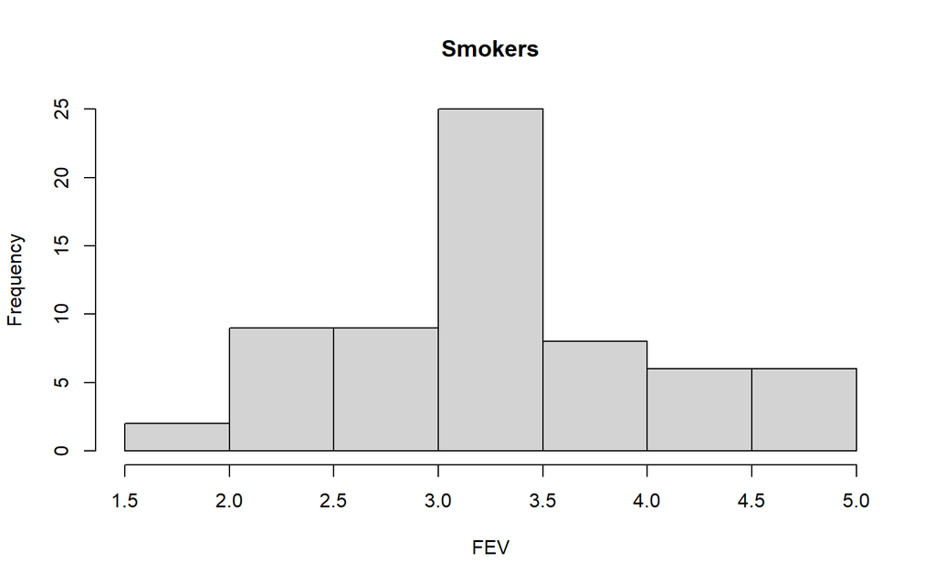

```r
hist(fev$fev[which(fev$smoke==1)], main="Smokers", xlab="FEV")
```

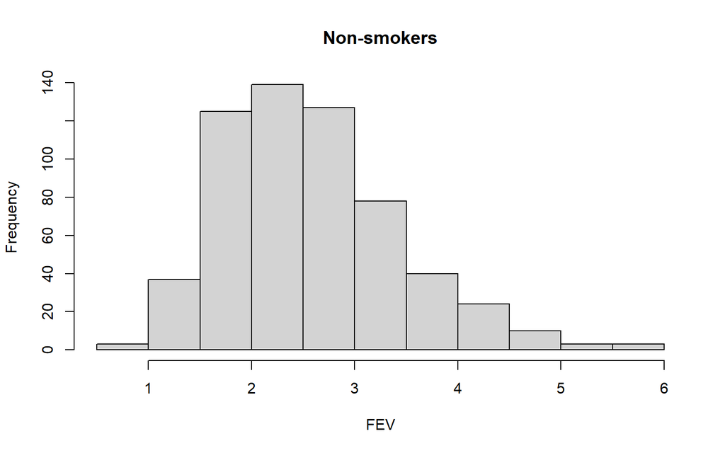

```r
hist(fev$fev[which(fev$smoke==2)], main="Non-smokers", xlab="FEV")
```

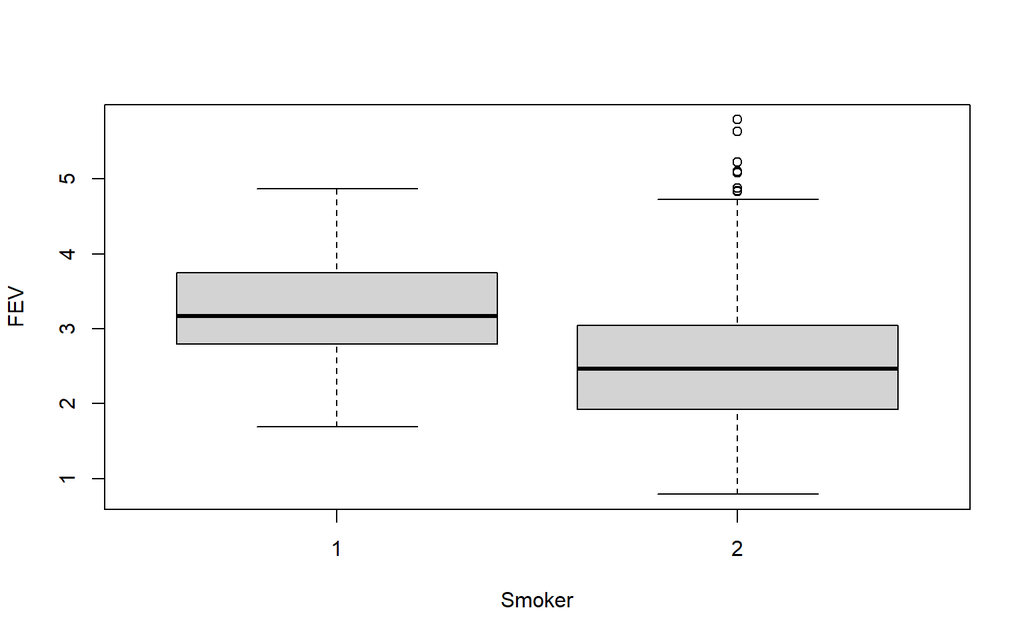

```r
boxplot(fev$fev~fev$smoke, main="", ylab="FEV", xlab="Smoker")
```

```r
tapply(fev$fev, fev$smoke,summary)
```

```
## $`1`
##    Min. 1st Qu.  Median    Mean 3rd Qu.    Max.
##   1.694   2.795   3.169   3.277   3.751   4.872
##
## $`2`
##    Min. 1st Qu.  Median    Mean 3rd Qu.    Max.
##   0.791   1.920   2.465   2.566   3.048   5.793
```

### Two-sample t-test (parametric)

T-statistic calculation

```r
#T statistic calculation
dataX=(fev$fev[which(fev$smoke==1)])
dataY=(fev$fev[which(fev$smoke==2)])

meanX=mean(dataX)
meanY=mean(dataY)
sdX=sd(dataX)
sdY=sd(dataY)
nX=length(dataX)
nY=length(dataY)

TValue=(meanX-meanY)/(sqrt(sdX^2/nX+sdY^2/nY))
TValue
```

```
## [1] 7.149608
```

Two-sample t-test

```r
t.test(dataX, dataY, alternative = "two.sided", paired = FALSE)
```

```
##
##  Welch Two Sample t-test
##
## data:  dataX and dataY
## t = 7.1496, df = 83.273, p-value = 3.074e-10
## alternative hypothesis: true difference in means is not equal to 0
## 95 percent confidence interval:
##  0.5130126 0.9084253
## sample estimates:
## mean of x mean of y
##  3.276862  2.566143
```

### Wilcoxon rank sum test (non-parametric):

Wilcoxon rank sum test is a non-parametric test for means of independent two samples.

```r
wilcox.test(dataX,dataY)
```

```
##
##  Wilcoxon rank sum test with continuity correction
##
## data:  dataX and dataY
## W = 28686, p-value = 4.071e-11
## alternative hypothesis: true location shift is not equal to 0
```

## Data example 2

We will use the **sot-covid** data used in “01_introduction”. The goal of this study was to compare humoral and cellular immune responses to two doses of the SARS-CoV-2 mRNA vaccine between solid organ transplant (SOT) recipients and healthy controls (HCs). See “01_introduction” for the details of this data.

```r
#load data
dataForAnalysis=read.csv("https://raw.githubusercontent.com/couthcommander/sip_computing/main/labs/sot-covid.csv",header=TRUE,row.names=1)

head(dataForAnalysis)
```

```
##   organ immuno mopost age male  rbd1  rbd2  rbd3  ecd1  ecd2  ecd3   nc1   nc2
## 1     0      0      0  55    1 0.426 0.755 1.889 0.417 0.749 1.716 0.184 0.207
## 2     0      0      0  72    1 0.098 1.018 2.632 0.184 0.880 2.151 0.130 0.049
## 3     0      0      0  80    0 0.153 0.289 1.720 0.243 0.362 1.404 0.333 0.352
## 4     0      0      0  57    0 0.118 1.446 2.329 0.148 1.463 1.983 0.095 0.107
## 5     0      0      0  56    1 0.154 0.632 2.119 0.158 0.403 1.468 0.191 0.211
## 6     0      0      0  53    1 0.124 0.961 2.270 0.127 0.988 1.805 0.147 0.085
##     nc3 bead_rbd1 bead_rbd2 bead_rbd3
## 1 0.248        43      1145     41469
## 2 0.146        24     20682    205766
## 3 0.256        16       346     14667
## 4 0.148        13      2120     37985
## 5 0.205        13       735     29884
## 6 0.125        12      2153     26098
```

## Comparing the mean of paired samples

Let’s compare Immunoglobulin G (IgG) to SARS-CoV-2 spike receptor-binding domain (RBD) values between the baseline (`rbd1`) and three weeks following first vaccine dose (`rbd2`).

### Paired t-test (parametric)

Data summary for changes in RBD between the baseline and three weeks following first vaccine dose

```r
summary(dataForAnalysis$rbd2-dataForAnalysis$rbd1)
```

```
##     Min.  1st Qu.   Median     Mean  3rd Qu.     Max.
## -0.19400 -0.01425  0.07300  0.36355  0.62875  1.92100
```

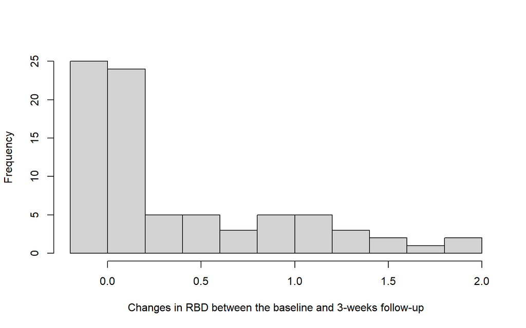

```r
hist(dataForAnalysis$rbd2-dataForAnalysis$rbd1, main="", xlab="Changes in RBD between the baseline and 3-weeks follow-up")
```

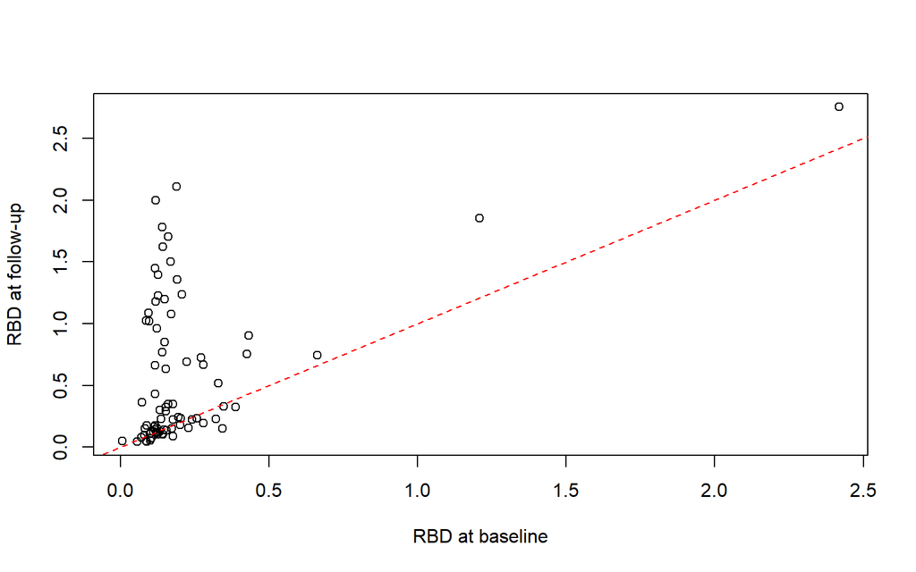

```r
plot(dataForAnalysis$rbd1, dataForAnalysis$rbd2, main="", xlab="RBD at baseline", ylab="RBD at follow-up")
abline(0, 1, lty=2, col="red")
```

T-statistic calculation on “difference”

```r
#T stastic caculation
diffValue=dataForAnalysis$rbd1-dataForAnalysis$rbd2

cohortMean=mean(diffValue)
cohortSD=sd(diffValue)
cohortN=length(diffValue)
populationMean=0

TValue=(cohortMean-populationMean)/(cohortSD/sqrt(cohortN))
TValue
```

```
## [1] -6.100996
```

Paired t-test

```r
t.test(dataForAnalysis$rbd1, dataForAnalysis$rbd2, paired = TRUE)
```

```
##
##  Paired t-test
##
## data:  dataForAnalysis$rbd1 and dataForAnalysis$rbd2
## t = -6.101, df = 79, p-value = 3.678e-08
## alternative hypothesis: true mean difference is not equal to 0
## 95 percent confidence interval:
##  -0.4821582 -0.2449418
## sample estimates:
## mean difference
##        -0.36355
```

You will get same results by one sample t-test to compare the difference with mean=0

```r
t.test(dataForAnalysis$rbd1-dataForAnalysis$rbd2, mu=0)
```

```
##
##  One Sample t-test
##
## data:  dataForAnalysis$rbd1 - dataForAnalysis$rbd2
## t = -6.101, df = 79, p-value = 3.678e-08
## alternative hypothesis: true mean is not equal to 0
## 95 percent confidence interval:
##  -0.4821582 -0.2449418
## sample estimates:
## mean of x
##  -0.36355
```

### Wilcoxon signed rank test (non-parametric)

Wilcoxon signed rank test is a non-parametric test for the mean of paired two samples.

```r
wilcox.test(dataForAnalysis$rbd1, dataForAnalysis$rbd2, paired = TRUE)
```

```
##
##  Wilcoxon signed rank test with continuity correction
##
## data:  dataForAnalysis$rbd1 and dataForAnalysis$rbd2
## V = 556, p-value = 3.381e-07
## alternative hypothesis: true location shift is not equal to 0
```

## Analysis of Variance (ANOVA): testing means for three or more samples

The ANOVA test assumes that the data are normally distributed and the variance across groups are homogeneous.

Let’s compare the baseline RBD values (`rbd1`) between different groups of organ transplant patients, as well as three weeks following first vaccine dose (`rbd2`).

*organ:* Transplant organ type (0 = healthy control, 1 = kidney, 2 = liver, 3 = heart, 4 = lung).

### Data visualization

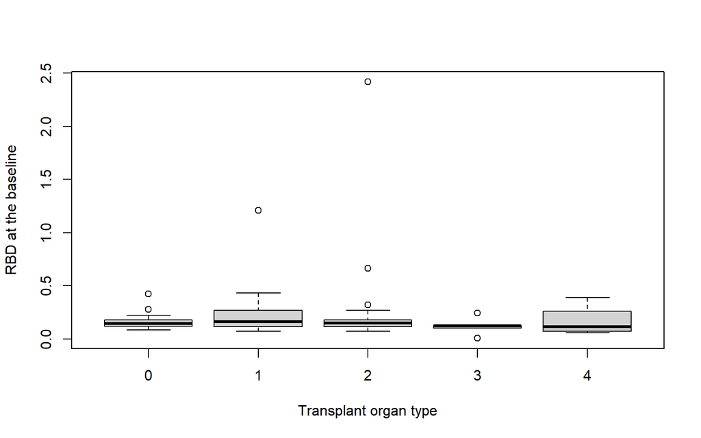

```r
boxplot(rbd1 ~ organ, data = dataForAnalysis, main="", xlab="Transplant organ type", ylab="RBD at the baseline")
```

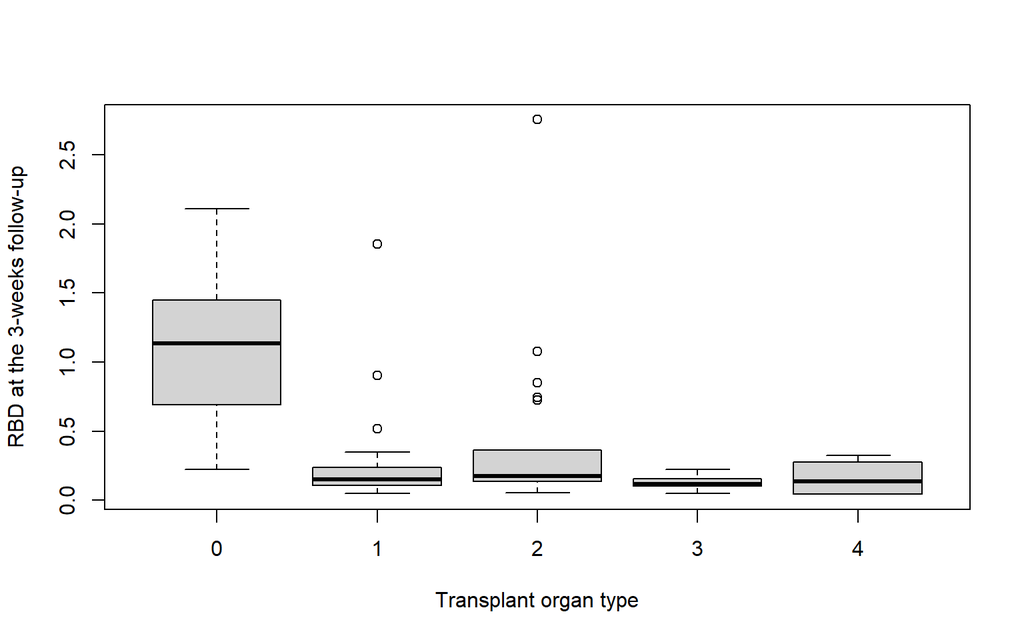

```r
boxplot(rbd2 ~ organ, data = dataForAnalysis, main="", xlab="Transplant organ type", ylab="RBD at the 3-weeks follow-up")
```

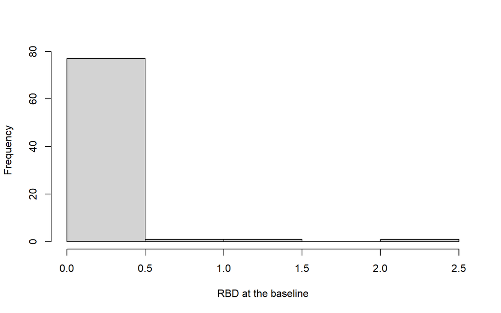

```r
hist(dataForAnalysis$rbd1, main="", xlab="RBD at the baseline")
```

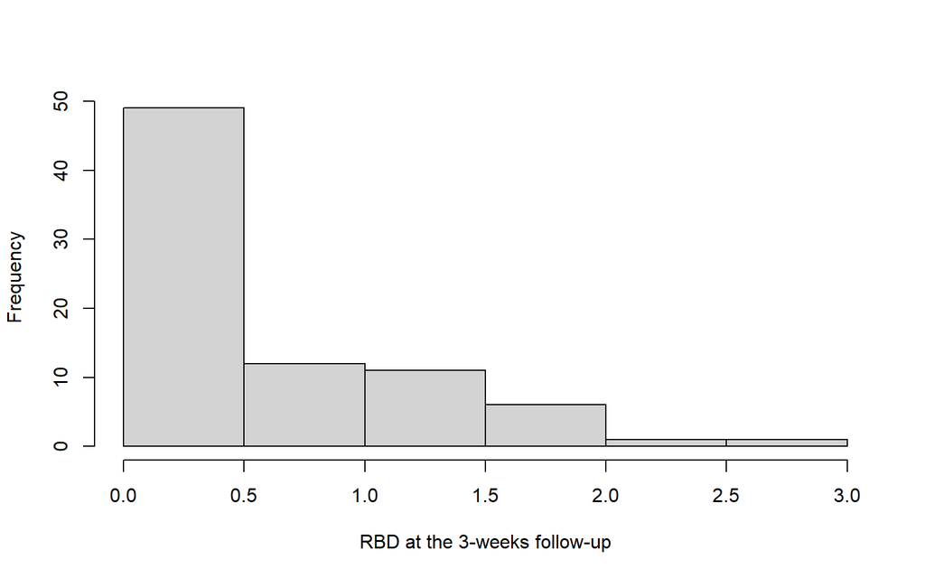

```r
hist(dataForAnalysis$rbd2, main="", xlab="RBD at the 3-weeks follow-up")
```

### One-way ANOVA

```r
dataForAnalysis$organ= factor(dataForAnalysis$organ)

#difference of baseline rbd between organ types
anovaResult1 <- aov(rbd1 ~ organ, data = dataForAnalysis)
summary(anovaResult1)
```

```
##             Df Sum Sq Mean Sq F value Pr(>F)
## organ        4  0.250 0.06262   0.719  0.581
## Residuals   75  6.528 0.08703
```

```r
#difference of rbd at three weeks following first vaccine dose between organ types
anovaResult2 <- aov(rbd2 ~ organ, data = dataForAnalysis)
summary(anovaResult2)
```

```
##             Df Sum Sq Mean Sq F value   Pr(>F)
## organ        4  11.84  2.9590   13.06 4.01e-08 ***
## Residuals   75  16.99  0.2265
## ---
## Signif. codes:  0 '***' 0.001 '**' 0.01 '*' 0.05 '.' 0.1 ' ' 1
```

### Tukey multiple pairwise-comparisons

```r
#TukeyHSD(anovaResult1)
TukeyHSD(anovaResult2)
```

```
##   Tukey multiple comparisons of means
##     95% family-wise confidence level
##
## Fit: aov(formula = rbd2 ~ organ, data = dataForAnalysis)
##
## $organ
##            diff        lwr        upr     p adj
## 1-0 -0.83267224 -1.2134640 -0.4518805 0.0000004
## 2-0 -0.67870330 -1.0689980 -0.2884086 0.0000604
## 3-0 -0.98651282 -1.5890069 -0.3840187 0.0001748
## 4-0 -0.95359615 -1.6680662 -0.2391261 0.0033011
## 2-1  0.15396894 -0.2475378  0.5554757 0.8202944
## 3-1 -0.15384058 -0.7636576  0.4559764 0.9547081
## 4-1 -0.12092391 -0.8415800  0.5997322 0.9898856
## 3-2 -0.30780952 -0.9236053  0.3079862 0.6313438
## 4-2 -0.27489286 -1.0006151  0.4508294 0.8268026
## 4-3  0.03291667 -0.8257695  0.8916028 0.9999695
```

### Kruskal-Wallis test

Kruskal-Wallis test is a non-parametric alternative to one-way ANOVA test, which extends Wilcoxon test rank sum test when there are more than two groups.

```r
#baselilne rbd
kruskal.test(rbd1 ~ organ, data = dataForAnalysis)
```

```
##
##  Kruskal-Wallis rank sum test
##
## data:  rbd1 by organ
## Kruskal-Wallis chi-squared = 3.0456, df = 4, p-value = 0.5502
```

```r
#rbd at three weeks following first vaccine dose
kruskal.test(rbd2 ~ organ, data = dataForAnalysis)
```

```
##
##  Kruskal-Wallis rank sum test
##
## data:  rbd2 by organ
## Kruskal-Wallis chi-squared = 39.836, df = 4, p-value = 4.68e-08
```

```r
pairwise.wilcox.test(dataForAnalysis$rbd2 , dataForAnalysis$organ,
                 p.adjust.method = "BH")
```

```
##
##  Pairwise comparisons using Wilcoxon rank sum exact test
##
## data:  dataForAnalysis$rbd2 and dataForAnalysis$organ
##
##   0       1      2      3
## 1 1.3e-07 -      -      -
## 2 4.9e-05 0.3181 -      -
## 3 1.1e-05 0.3181 0.0946 -
## 4 0.0013  0.4539 0.3181 1.0000
##
## P value adjustment method: BH
```